# Final Project, Assignment 2: R Markdown

Elaina Sinclair

2026-09-27

# Introduction

This report uses the Alzheimer’s Disease Dataset (El Kharoua, 2024), a synthetic dataset available on Kaggle that contains health records for 2,149 patients aged 60 to 90 years. The full dataset includes demographics, lifestyle factors, medical history, clinical measurements, cognitive and functional assessments, symptoms, and an Alzheimer’s disease diagnosis. This report uses a subset of these variables. The outcome of interest is Alzheimer’s disease diagnosis (yes/no). Demographic variables include age (years), gender (male/female), ethnicity (White, Black, Asian, or Other), and education level (none, high school, bachelor’s, or higher). Lifestyle and medical history variables include body mass index (BMI), smoking status, family history of Alzheimer’s disease, and hypertension, each recorded as yes/no, except BMI. Cognitive and functional status is measured by three scores: the Mini-Mental State Examination (MMSE; 0–30), a Functional Assessment score (0–10), and an Activities of Daily Living (ADL) score (0–10), with lower scores indicating greater impairment on all three. The report also includes two yes/no symptom indicators: memory complaints and behavioral problems.

The objectives of this report are to (1) compare patient characteristics by diagnosis status and (2) estimate how cognitive and functional measures and symptoms are associated with the odds of diagnosis, adjusting for age and gender.

It’s important to emphasize that this report uses a *synthetic* Kaggle dataset (El Kharoua, 2024). Results are intended to demonstrate analytic methods rather than to describe real-world relationships.

# Descriptive Analysis

**Table 1. Patient characteristics by Alzheimer’s diagnosis** (continuous variables: mean (SD); categorical variables: n (%))

| **Characteristic** | **Overall** N = 2,149<sup>1</sup> | **Alzheimer’s** N = 760<sup>1</sup> | **No Alzheimer’s** N = 1,389<sup>1</sup> | **p-value**<sup>2</sup> |
| --- | --- | --- | --- | --- |
| Age | 74.9 (9.0) | 74.8 (9.1) | 74.9 (8.9) | 0.8 |
| Gender |  |  |  | 0.3 |
| Male | 1,061 (49%) | 386 (51%) | 675 (49%) |  |
| Female | 1,088 (51%) | 374 (49%) | 714 (51%) |  |
| Ethnicity |  |  |  | 0.10 |
| White | 1,278 (59%) | 463 (61%) | 815 (59%) |  |
| Black | 454 (21%) | 146 (19%) | 308 (22%) |  |
| Asian | 206 (9.6%) | 84 (11%) | 122 (8.8%) |  |
| Other | 211 (9.8%) | 67 (8.8%) | 144 (10%) |  |
| Education |  |  |  | 0.2 |
| None | 446 (21%) | 174 (23%) | 272 (20%) |  |
| High School | 854 (40%) | 302 (40%) | 552 (40%) |  |
| Bachelor's | 636 (30%) | 217 (29%) | 419 (30%) |  |
| Higher | 213 (9.9%) | 67 (8.8%) | 146 (11%) |  |
| BMI | 27.7 (7.2) | 27.9 (7.3) | 27.5 (7.2) | 0.2 |
| Smoking | 620 (29%) | 217 (29%) | 403 (29%) | 0.8 |
| Family History of AD | 542 (25%) | 177 (23%) | 365 (26%) | 0.13 |
| Hypertension | 320 (15%) | 126 (17%) | 194 (14%) | 0.10 |
| MMSE | 14.8 (8.6) | 12.0 (7.2) | 16.3 (8.9) | <0.001 |
| Functional Assessment | 5.1 (2.9) | 3.7 (2.6) | 5.9 (2.8) | <0.001 |
| ADL | 5.0 (2.9) | 3.7 (2.7) | 5.7 (2.8) | <0.001 |

<sup>1</sup> Mean (SD); n (%)  
<sup>2</sup> Welch Two Sample t-test; Pearson’s Chi-squared test

Table 1 summarizes the characteristics of the 2,149 patients in the dataset, overall and by diagnosis status: 760 (35%) with Alzheimer’s disease and 1,389 without. Demographic, lifestyle, and medical history characteristics were similar between the two groups. Mean age was about 75 years in both groups (74.8 vs. 74.9; p = 0.8), and there were no statistically significant differences in gender, ethnicity, education, BMI, smoking, family history of Alzheimer’s disease, or hypertension (all p ≥ 0.05). By contrast, patients with Alzheimer’s scored substantially lower on all three cognitive and functional measures: mean MMSE was 12.0 vs. 16.3, mean Functional Assessment was 3.7 vs. 5.9, and mean ADL was 3.7 vs. 5.7 (all p < 0.001). Lower scores indicate greater impairment, so these differences suggest worse cognitive function and daily functioning among patients with an Alzheimer’s diagnosis.

# Regression Analysis

**Table 2. Logistic regression of Alzheimer’s diagnosis**

| **Characteristic** | **OR** | **95% CI** | **p-value** |
| --- | --- | --- | --- |
| Age | 0.99 | 0.98, 1.00 | 0.15 |
| Gender |  |  |  |
| Male | — | — |  |
| Female | 0.94 | 0.74, 1.21 | 0.6 |
| MMSE | 0.90 | 0.88, 0.91 | <0.001 |
| Functional Assessment | 0.64 | 0.61, 0.67 | <0.001 |
| ADL | 0.66 | 0.63, 0.69 | <0.001 |
| Memory Complaints |  |  |  |
| No | — | — |  |
| Yes | 13.4 | 9.74, 18.6 | <0.001 |
| Behavioral Problems |  |  |  |
| No | — | — |  |
| Yes | 12.0 | 8.47, 17.3 | <0.001 |

Abbreviations: CI = Confidence Interval, OR = Odds Ratio

Table 2 shows odds ratios (ORs) and 95% confidence intervals from a logistic regression of Alzheimer’s diagnosis on age, gender, cognitive and functional scores, and symptoms, with each variable adjusted for all the others. Age (OR = 0.99, 95% CI: 0.98–1.00; p = 0.15) and gender (female vs. male OR = 0.94, 95% CI: 0.74–1.21; p = 0.6) were not significantly associated with diagnosis. Higher cognitive and functional scores were each associated with lower odds of an Alzheimer’s diagnosis: each 1-point increase in MMSE was associated with 10% lower odds of Alzheimer’s diagnosis (OR = 0.90, 95% CI: 0.88–0.91), each 1-point increase in Functional Assessment with 36% lower odds of Alzheimer’s diagnosis (OR = 0.64, 95% CI: 0.61–0.67), and each 1-point increase in ADL with 34% lower odds of Alzheimer’s diagnosis (OR = 0.66, 95% CI: 0.63–0.69; all p < 0.001). The two symptom variables had the strongest associations: patients with memory complaints had about 13 times the odds of Alzheimer’s diagnosis compared with those without (OR = 13.4, 95% CI: 9.74–18.6; p < 0.001), and patients with behavioral problems had about 12 times the odds of Alzheimer’s diagnosis (OR = 12.0, 95% CI: 8.47–17.3; p < 0.001).

# Figure

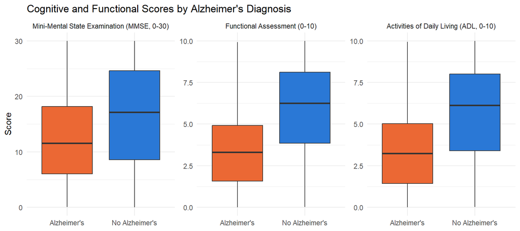

Figure 1 shows the distributions of the three cognitive and functional scores by Alzheimer’s diagnosis status. On all three measures, patients with Alzheimer’s (orange) had lower scores than patients without Alzheimer’s (blue), indicating greater impairment. Median MMSE was 11.6 in the Alzheimer’s group vs. 17.1 in the no-Alzheimer’s group. Median Functional Assessment and ADL scores were each about 3 (Alzheimer’s) vs. about 6 (No Alzheimer’s). The gap in scores is widest for Functional Assessment and ADL, where the middle 50% of scores for the Alzheimer’s group is mostly below the middle 50% for the no-Alzheimer’s group. Even so, the two groups overlap substantially on every measure, and scores in both groups span nearly the full possible range. These visual patterns are consistent with the mean differences in Table 1 and with the odds ratios in Table 2.